# NI-KOP

Author: Mykyta Boiko

CTU login: boikomyk

## Report #5

## Popis problému

Dána Booleova formule **F** o n proměnných, **X**=(x1, x2, ... , xn) v konjunktivní normální formě (CNF). Dále jsou dány celočíselné kladné váhy těchto n proměnných **W**=(w1, w2, ... , wn). Nalezněte přiřazení **Y**=(y1, y2, ... , yn) proměnných x1, x2, ... , xn, takové, že **F**(Y)=1 a součet S vah proměnných nastavených do 1 je maximální.

## Výběr algoritmu

Byly nabídnuté následující heuristické algoritmy:

- Simulované ochlazování
- Genetické algoritmy
- Tabu search

Pro řešení problému vážené splnitelnosti booleovské formule jsem zvolil heruistiku **Simulované ochlazování**.

## Simulované ochlazování

#### Pseudokód (*přednaska č.8, str.14*)

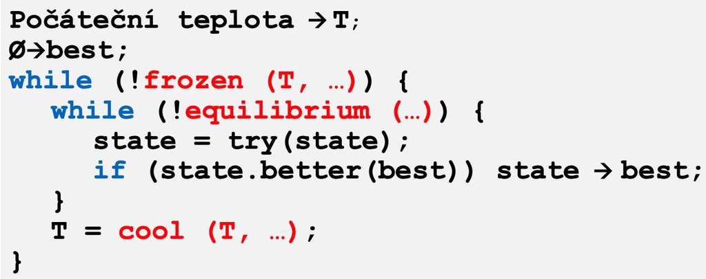

**Simulované ochlazování** je iterativní heruistika. Snaží se určitého počátečního řešení postupně dopracovat k řešení co nejlepšímu.

Zajimova vlasnost algoritmu je, že se snaží v jednotlivých iteracích uniknout z lokálního minima tím, že může dočasně přijmout horší výsledek. Algoritmus nezaručuje nalezení ideálně optimálního výsledků, přesto může za konstantní počet kroku najít docela příjemný výsledek.

Základní parametry algoritmu jsou:

- $\text{počáteční stav}$
- $\text{počáteční teplota}$
- $\text{koeficient ochlazování} \in [0.8,0.99]$
- $\text{koncová(/minimální) teplota}$
- $\text{equilibrium}$

Na začátku algoritmus dostane počáteční stav, t.j. libovolnou konfiguraci, která je řešením. Algoritmus běží, dokud z počáteční teploty nedosáhne minimální teploty, ke které se dostává tak, že postupně násobí aktuální teplotu koeficientem ochlazování (aby aktuální teplota se zmenšovala). V algoritmu zmíněnou funkcionalitu implementuje fukce $\textbf{frozen()} $ (vnější cyklus). Ochlazování teploty je implementované funkci $\textbf{cool()} $ na konci vnějšího cylku. Vnitřní cyklus je implementován funkci $\textbf{equilibrium()} $, která definuje pevný počet kroku, t.j. počet iteraci na daně teplotě, rovný: $ N_{CelkovyPocetLiteralů} * equilibrium $.

V každém kroku vnitřního cyklu je volaná funkce $\textbf{try()} $. Unvitr této funci generuje se *sousední stav*, t.j. sousední řešení(/konfigurace), která se liší jenom inverzi hanodneho bitů aktuálního stavu(t.j změna ohodnocení nějakého literalu, nastavení jej na True nebo False). Pokud je sousední stav lepší než aktuální, tak je vždy přijat. Pokud není, tak bude přijat na základě pravděpodobností danou formuli: $$ \text{Pravděpodobnost přijetí} = e^{-\frac{CenaSousednihoStavu - AktualniCena}{AktualniTeplota}} $$ Tato pravděpodobnost bude porovnána s náhodným číslem z intervalu $[0,1]$. Z toho vlastně plynou následující zákonitosti: čím je horší řešení, tím je menší pravděpodobnost, že bude přijato. Avšak, čím je větší aktuální teplota, tím je větší šanci toho, že poměrně horší řešení bude přijato. Tohle právě znázorňuje princip uniknutí z lokálního minima.

Po ukončení vnitřního cyklu je snížena aktuální teplota. Pokud se došlo k minimální teplotě, tak algoritmus se zastaví a vrátí nalezeny výsledek.

Algoritmus je do detailů popsaný a okomentovaný přímo v kódu.

#### Zkrácený kód:

```
# repeat this process until the current temperature is less than the final temperature
        while not self._frozen():
            iteration = 0
            # stay on this temperature for a while (equilibrium)
            while self._equilibrium(iteration):
                # get a random neighbor of the current state
                self.state = self._try()

                if self.state.better(best_state) and self.state.is_valid():
                    # update best state
                    best_state = deepcopy(self.state)

                # increment counters
                iteration += 1

            # reduce the temperature on each iteration
            self.current_temperature = self._cool()
```

## Modifikace oproti problému bathou

Důležitá modifikace oproti problémů batohu je způsob výpočtu ohodnocení stavu. Základ je následující: součet vah literalů, které jsou ohodnoceny 1. Primární cíl maximalizace tohoto součtu. Avask spočívá v tom velký problém, že algoritmus by vůbec nehledal správné řešení, ale skončil by se všemi literaly nastavenými na 1. Prozkoumal jsem spoustu různých zdrojů a experimentálně zkoušel jsem různé přístupy jak správné definovat cenovou funkci pro problém vážené splnitelnosti booleovské formule. Kazdy z přístupů rychle probereme.

#### - cena ovlivněná počtem splněných klauzulí

```
def cost_affected_by_count_of_satisfied_clauses(self) -> int:
    """
    Returns current state's cost: total weight is multiplied by satisfied clauses count
    """
    weight = self.sat_problem.weight(self.configuration)
    return int(weight * self.sat_problem.true_clauses_cnt(self.configuration))
```

$$ \text{Cena stavu} = Vaha \times PočetSplněnýchKlauzulí $$

Výsledná cena v tomto případě byla definována součinem váhy a počtem splněných splněných klauzuli. Tímto přístupem jsem chtěl zvýhodňovat řešení, co mají větší počet splněných klauzuli. Avšak tohle řešení nevždy udávala příjemné výsledky. Proto jsem pokračoval zkoušet další přístupy. A chtěl jsem zkusit úplně obrácený přístup.

#### - cena ovlivněná koefficientem pro nesplnene klauzuli

```
def cost_affected_by_unsatisfied_penalty_coefficient(self, unsatisfied_penalty_coefficient: int) -> int:
    """
    Returns current state's cost: the number of unsatisfied clauses multiplied by maximum weight over all literals
    and multiplied by unsatisfied_penalty_coefficient and then subtracted from the total weight
    """
    weight = self.sat_problem.weight(self.configuration)
    unsatisfied_clauses_cnt = self.sat_problem.clauses_cnt - self.sat_problem.true_clauses_cnt(self.configuration)
    return int(weight - (unsatisfied_clauses_cnt * max(self.sat_problem.weights) * unsatisfied_penalty_coefficient))
```

$$ \text{Cena stavu} = Vaha - (PočetNesplněnýchKlauzulí \times MaximalníVahaLiteralu \times KoeficientemNeuspokojení) $$

Výsledná cena byla definována rozdílem mezi vahou a počtem nesplněných klauzulí vynásobeným maximální váhou přes všechny literály a vynásobenym "koeficientem neuspokojení". Hodnotu koefficientu jsem volil experementalne z intervalu [1, 10]. Dá se říct, že tahle implementace už vedla na relativně dobře výsledky. Avšak chtěl jsem zkusit ještě další přístupy, resp. přístup který by bral do úvahy jestli je formule splněna nebo ne.

#### - cena ovlivněná penalty koefficientem

```
def cost_affected_by_penalty_coefficient(self, penalty_coefficient: int) -> int:
    """
    Returns current state's cost affected by penalty coefficient
    """
    weight = self.sat_problem.weight(self.configuration)

    # F(configuration) = 1
    if self.sat_problem.is_solution(self.configuration):
        return weight * penalty_coefficient
    # F(configuration) != 1
    return int(weight * pow(self.sat_problem.true_clauses_ratio(self.configuration), penalty_coefficient))
```

$$ \text{Cena stavu(F=1)} = Vaha \times PenaltyKoefficient $$$$ \text{Cena stavu(F!=1)} = Vaha \times PoměrSplněnýchKlauzulí^{PenaltyKoefficient} $$

Stejně jak u předchozího návrhu přidal jsem závislost ceny na novém koefficientu. Avask teď se rozlišovaly případy pro splněnou formule a ne. V případě F=1, tak výsledná cena byla váha vynásobená penalty koefficientem. V opracnem případě váha vynásobená poměrem splněných klauzuli na mocninu penalty koefficientu. Tahle implementace dle mě udávala nejpříjemnější výsledky. Hodnotu koefficientu jsem volil experementalne (bude uvedeno dále).

Všechny výš popsané implementace byly použité ve funcki $\textbf{better()}$. Po několika experimentech jsem se rozhodl použít v finálním programu poslední variantu, protože ve většině případů udávala nejlepší výsledky.

## Předzpracování a generování dát

Dále budou definované pomůcné funcke pro generování/načtení testovacích(vstupních) dát, řešení a vyklresleni výsledků experimentů.

```python
# import scope
import numpy as np
import pandas as pd
from io import StringIO
import matplotlib
import seaborn as sns
import matplotlib.pyplot as plt
from typing import Dict
from prettytable import PrettyTable

%matplotlib inline
```

```python
# path to solver executor
SOLVER = '../../sat/main.py'
```

```python
!python3.9 $SOLVER --help | tail -n 20
```

```
Process input problem instances.

optional arguments:
  -h, --help            show this help message and exit
  -in INPUT, --input INPUT
                        paste path to input file
  -ref REFERENCE, --reference REFERENCE
                        paste path to file containing solution/reference
  -state_generator {InitialStateGenerator.all_false,InitialStateGenerator.random}, --state_generator {InitialStateGenerator.all_false,InitialStateGenerator.random}
  -initial_temperature INITIAL_TEMPERATURE, --initial_temperature INITIAL_TEMPERATURE
                        initial temperature
  -cooling_coefficient COOLING_COEFFICIENT, --cooling_coefficient COOLING_COEFFICIENT
                        cooling coefficient
  -minimal_temperature MINIMAL_TEMPERATURE, --minimal_temperature MINIMAL_TEMPERATURE
                        minimal temperature
  -equilibrium_coefficient EQUILIBRIUM_COEFFICIENT, --equilibrium_coefficient EQUILIBRIUM_COEFFICIENT
                        equilibrium coefficient
  -penalty_coefficient PENALTY_COEFFICIENT, --penalty_coefficient PENALTY_COEFFICIENT
                        equilibrium coefficient
  -b, --benchmark       display benchmark
```

#### Základní nastavení parametrů algoritmu:

| 1 | Počáteční teplota | 100 |
| --- | --- | --- |
| 2 | Koeficient ochlazování | 0.9 |
| 3 | Minimální teplota | 10 |
| 4 | Equilibrium | 3 |
| 5 | Generátor počátečního stavu | all_false |

Přidal jsem 5-tý parameter do algoritmu, který vlastně říká jak bude generovaný počáteční stav. Pro tyto účely jsem naimplementoval 2 možnosti:

- **all_false**: ohodnocení všech literalu nastaveno na False
- **random**: náhodně ohodnocení literalů

Co se tyce **-penalty_coefficient**, vysvětlení, jak zjistit správnou hodnotu tohoto parametru, bude uvedeno dále.

```python
# common constants scope

INITIAL_TEMPERATURE = 100
COOLING_COEFFICIENT = 0.9
MINIMAL_TEMPERATURE = 10
EQUILIBRIUM = 3
INITIAL_STATE_GENERATOR = 'all_false'


DEFAULT_ARGS = {
    '-initial_temperature'    : INITIAL_TEMPERATURE,
    '-cooling_coefficient'    : COOLING_COEFFICIENT,
    '-minimal_temperature'    : MINIMAL_TEMPERATURE,
    '-equilibrium_coefficient': EQUILIBRIUM,
    '-state_generator'        : INITIAL_STATE_GENERATOR,
    '-penalty_coefficient'    : 5 # An explanation of finding the correct value for this parameter will be explained a little bit later
}
```

V ramci zadani byly poskytnuty sady zkušebních instanci **wuf-M** vcetne optimalnich reseni pro nektere instanci.

```python
!ls -la '../../sat/data/wuf-M/' | tail -n 5
```

```
drwxr-xr-x@ 1002 user  staff  - 32064 Dec  7  2019 wuf20-78-M/
-rw-r--r--@    1 user  staff  - 73619 Dec  7  2019 wuf20-78-M-opt.dat
drwxr-xr-x@ 1002 user  staff  - 32064 Dec  7  2019 wuf50-201-M/
-rw-r--r--@    1 user  staff  -  5948 Dec  7  2019 wuf50-201-M-opt.dat
drwxr-xr-x@  102 user  staff  -  3264 Dec  7  2019 wuf75-310-M/
```

Potřebujeme měřit relativní chybu, proto měření budeme provádět pouze na instancích pro které existuje příslušné referenční řešení. Soustředíme hlavně na instancích ze souboru **wuf50-201-M**, kde každá instance má:

- 50 literalů
- 201 klauzulí

Všechny měření budeme provádět na **10** instancích z tohoto souboru. Výsledky budou zprůmerovany.

Takže zvolíme 10 náhodných souboru dle referenčního souboru. Bohužel jsem omezený výpočetním výkonem svého počítače a nemůžu čekat více než několik hodin na zpracování vstupních instanci, proto omezil jsem se pouze na 10 instancích.

```python
first_10_files = !head -10 $PATH_TO_REFERENCE | cut -d' ' -f1


PATH_TO_REFERENCE  = f'../../sat/data/wuf-M/wuf50-201-M-opt.dat'
INPUT_FILES = [
    f'w{input_file_name}.mwcnf' for input_file_name in first_10_files.n.split('\n')
]
print(*INPUT_FILES)
PATH_TO_INPUT_FILES = f'../../sat/data/wuf-M/wuf50-201-M/'
```

```
wuf50-0123.mwcnf wuf50-012.mwcnf wuf50-0133.mwcnf wuf50-0139.mwcnf wuf50-0241.mwcnf wuf50-024.mwcnf wuf50-0274.mwcnf wuf50-0369.mwcnf wuf50-036.mwcnf wuf50-0405.mwcnf
```

```python
# prepare help functions for data predprocessing
def read_and_store_buffer_input_to_df(buffer):
    # read csv input
    df = pd.read_table(buffer, delimiter="\t", index_col=False, low_memory=False)
    return df
```

```python
def solve_instance_using_simulated_annealing(
    parameter_with_range_to_test: Dict[str,str],
    args: Dict[str,str] = DEFAULT_ARGS,
    log_events = True
):
    # remove from args tesing param
    parameter_name = next(iter(parameter_with_range_to_test.keys()))
    del args[parameter_name]

    # get valid args str
    args_str = " ".join(map(lambda arg: f"{arg[0]}={arg[1]}", args.items()))

    # prepare storage for algorithms outputs

    algorithm_outputs = []
    for parameter_value in next(iter(parameter_with_range_to_test.values())):
        if log_events: print(f'\x1b[1;32m[INFO]\x1b[0m: testing parameter \x1b[1;31m {parameter_name}={parameter_value}\x1b[0m')

        # prepare args (inlcuding param to test)
        args_with_test_param = f'{args_str} {parameter_name}={parameter_value}'

        if log_events: print(f' - Solving input instances.. :', end='')

        for indx, input_file_name in enumerate(INPUT_FILES):
            # ala progress bar
            if log_events: print(f"{input_file_name}, ", end="") if indx != len(INPUT_FILES)-1 else print(f"{input_file_name}..\n", end="")

            input_file = f'{PATH_TO_INPUT_FILES}{input_file_name}'
            # solve input instace and obtain solution
            solution = !python3.9 $SOLVER -in=$input_file -ref=$PATH_TO_REFERENCE -b $args_with_test_param

            # store solution output to dataframe
            df = read_and_store_buffer_input_to_df(
                buffer=StringIO(solution.n)
            )
            # update dataframe with corresponding column representing testing parameter
            df[parameter_name]=parameter_value
            algorithm_outputs.append(df)

    # concatenate all dataframes to single dataframe
    return pd.concat(algorithm_outputs).reset_index()
```

```python
def plot_basic_analytics(
    algorithm_outputs: pd.DataFrame,
    parameter_with_range_to_test: Dict[str,str],
    index_column: str,
    parameter_label: str
):
    # define several pivot tables for different analytic cases
    spawn_pivot_table = lambda value, aggfunc: pd.pivot_table(
        data=algorithm_outputs,
        values=value,
        index=index_column,
        aggfunc=np.mean
    )

    # Mean for: time, steps, error
    time_mean_table = spawn_pivot_table(value='TIME[ms]', aggfunc=np.mean)
    steps_mean_table = spawn_pivot_table(value='STEPS', aggfunc=np.mean)
    error_mean_table = spawn_pivot_table(value='ERROR', aggfunc=np.mean)

    df_sat_analytics = algorithm_outputs.copy()
    data = {
    'NOT_SAT': [],
    'SAT': [],
    'OPTIMAL_SAT': []
    }
    parameter_name = next(iter(parameter_with_range_to_test.keys()))
    for value in next(iter(parameter_with_range_to_test.values())):
        data['NOT_SAT'].append(df_sat_analytics[(df_sat_analytics['SATISFIED'] == False) & (df_sat_analytics[parameter_name] == value)].count()['SATISFIED'])
        data['SAT'].append(df_sat_analytics[(df_sat_analytics['SATISFIED'] == True) & (df_sat_analytics[parameter_name] == value)].count()['SATISFIED'])
        data['OPTIMAL_SAT'].append(df_sat_analytics[
            (df_sat_analytics['SATISFIED'] == True) &
            (df_sat_analytics['ERROR'] == 0.0) &
            (df_sat_analytics[parameter_name] == value)
        ].count()['SATISFIED'])

    df_sat = pd.DataFrame(data, index = next(iter(parameter_with_range_to_test.values())))

    _, axes = plt.subplots(nrows=1, ncols=2, figsize=(22,7))

    ax = steps_mean_table.plot(title=f"Průměr počet kroků VS {parameter_label}", ax=axes[0])
    ax.set_ylabel('Průměr počtu kroků')
    ax.set_xlabel(parameter_label)

    ax = error_mean_table.plot(title=f"Průměr relativní chyby VS {parameter_label}", ax=axes[1])
    ax.set_ylabel('Průměr relativní chyby')
    ax.set_xlabel(parameter_label)

    _, axes = plt.subplots(nrows=1, ncols=2, figsize=(22,7))

    ax = time_mean_table.plot(title=f"Průměr času v mikrosekundech VS {parameter_label}", ax=axes[0])
    ax.set_ylabel('Průměr času v mikrosekundech')
    ax.set_xlabel(parameter_label)

    ax = df_sat.plot(y=["NOT_SAT", "SAT", "OPTIMAL_SAT"], use_index=True, title=f"Počet problemů VS {parameter_label}", ax=axes[1])
    ax.set_ylabel('Počet problémů')
    ax.set_xlabel(parameter_label)


    plt.show()
```

```python
def display_sat_table_analysis(
    parameter_with_range_to_test: Dict[str,str],
    df: pd.DataFrame

):
    parameter_name = next(iter(parameter_with_range_to_test.keys()))
    t = PrettyTable([parameter_name, 'Počet není SAT rešení', 'Počet SAT rešení', 'Počet optimalních SAT rešení'])

    df_analytics = df.copy()

    for value in next(iter(parameter_with_range_to_test.values())):
        NOT_SAT = df_analytics[(df_analytics['SATISFIED'] == False) & (df_analytics[parameter_name] == value)].count()['SATISFIED']
        SAT = df_analytics[(df_analytics['SATISFIED'] == True) & (df_analytics[parameter_name] == value)].count()['SATISFIED']
        OPTIMAL_SAT = df_analytics[
            (df_analytics['SATISFIED'] == True) &
            (df_analytics['ERROR'] == 0.0) &
            (df_analytics[parameter_name] == value)
        ].count()['SATISFIED']

        t.add_row([value, NOT_SAT, SAT, OPTIMAL_SAT])

    print(f"\nCelkovy počet problémů {len(INPUT_FILES)}")
    print(t)
```

```python
def plot_weight_evalution_history(
    algorithm_output: pd.DataFrame,
    parameter_column_name: str,
    index_values
):
    index_values = index_values[:4]
    _, axes = plt.subplots(nrows=2, ncols=2, figsize=(20,11))

    x = 0
    y = 0
    for index_value in index_values:
        dataframe = algorithm_output.loc[algorithm_output[parameter_column_name] == index_value]

        price_history_table = pd.DataFrame(data={
            'WEIGHT_HISTORY': dataframe['WEIGHT_HISTORY'].iloc[0].split(','),
        })
        # append STEPS column
        price_history_table["STEPS"] = price_history_table.index + 1

        # define several pivot tables for different analytic cases
        spawn_pivot_table = lambda value, aggfunc: pd.pivot_table(
            data=price_history_table,
            values=value,
            index='STEPS',
            aggfunc=np.mean
        )
        price_mean_table = spawn_pivot_table(value='WEIGHT_HISTORY', aggfunc=np.mean)

        ax = price_mean_table.plot(title=f"{parameter_column_name}={index_value}", ax=axes[x, y])
        ax.set_ylabel('Vyvoj vahy')
        ax.set_xlabel('Počet kroků/Iterace')

        if y == 1:
            x = 1
            y = 0
        else:
            y += 1

    plt.suptitle('Vyvoj vahy VS Počet navštívených stavů/kroků',fontsize=18)

    plt.show()
```

```python
def plot_history_columns_evalution(
    algorithm_output: pd.DataFrame
):
    history_table = pd.DataFrame(data={
        'WEIGHT': algorithm_output['WEIGHT_HISTORY'].iloc[0].split(','),
        'COST': algorithm_output['COSTS_HISTORY'].iloc[0].split(','),
        'TEMPERATURE': algorithm_output['TEMPERATURE_HISTORY'].iloc[0].split(',')
    })
    # append STEPS column
    history_table["STEPS"] = history_table.index + 1

    history_table["WEIGHT"]=history_table["WEIGHT"].astype(int)
    history_table["COST"]=history_table["COST"].astype(float)
    history_table["TEMPERATURE"]=history_table["TEMPERATURE"].astype(float)


    # define several pivot tables for different analytic cases
    spawn_pivot_table = lambda value, aggfunc: pd.pivot_table(
        data=history_table,
        values=value,
        index='STEPS',
        aggfunc=np.mean
    )

    temperatue_mean_table = spawn_pivot_table(value='TEMPERATURE', aggfunc=np.mean)

    _, axes = plt.subplots(nrows=1, ncols=2, figsize=(15,7))

    ax = history_table.plot(y=['WEIGHT', 'COST'], x='STEPS', title=f"Vyvoj vahy a ceny VS Počet kroků", ax=axes[0])
    ax.set_ylabel('Vyvoj vahy a ceny')
    ax.set_xlabel('Počet kroků/Iterace')

    ax = temperatue_mean_table.plot(title=f"Vyvoj teploty VS Počet kroků", ax=axes[1])
    ax.set_ylabel('Vyvoj teploty')
    ax.set_xlabel('Počet kroků/Iterace')

    plt.show()
```

## Analýza a interpretace dat

#### Penalty koefficient [ $\textbf{-penalty_coefficient}$ ]

Nejdřív potřebujeme určit optimální hodnotu parametru penálty koefficientu. Pro testování zvolíme interval $[1, 10]$ s krokem 1.

```python
args = DEFAULT_ARGS.copy()

penalty_coefficient_parameter = {
    # range -penalty_coefficient <1, 10>
    '-penalty_coefficient': range(1, 10 + 1, 1)
}

algorithm_outputs_penalty_coefficient = solve_instance_using_simulated_annealing(
    parameter_with_range_to_test=penalty_coefficient_parameter,
    args=args
)
```

```
[INFO]: testing parameter  -penalty_coefficient=1
 - Solving input instances.. :wuf50-0123.mwcnf, wuf50-012.mwcnf, wuf50-0133.mwcnf, wuf50-0139.mwcnf, wuf50-0241.mwcnf, wuf50-024.mwcnf, wuf50-0274.mwcnf, wuf50-0369.mwcnf, wuf50-036.mwcnf, wuf50-0405.mwcnf..
[INFO]: testing parameter  -penalty_coefficient=2
 - Solving input instances.. :wuf50-0123.mwcnf, wuf50-012.mwcnf, wuf50-0133.mwcnf, wuf50-0139.mwcnf, wuf50-0241.mwcnf, wuf50-024.mwcnf, wuf50-0274.mwcnf, wuf50-0369.mwcnf, wuf50-036.mwcnf, wuf50-0405.mwcnf..
[INFO]: testing parameter  -penalty_coefficient=3
 - Solving input instances.. :wuf50-0123.mwcnf, wuf50-012.mwcnf, wuf50-0133.mwcnf, wuf50-0139.mwcnf, wuf50-0241.mwcnf, wuf50-024.mwcnf, wuf50-0274.mwcnf, wuf50-0369.mwcnf, wuf50-036.mwcnf, wuf50-0405.mwcnf..
[INFO]: testing parameter  -penalty_coefficient=4
 - Solving input instances.. :wuf50-0123.mwcnf, wuf50-012.mwcnf, wuf50-0133.mwcnf, wuf50-0139.mwcnf, wuf50-0241.mwcnf, wuf50-024.mwcnf, wuf50-0274.mwcnf, wuf50-0369.mwcnf, wuf50-036.mwcnf, wuf50-0405.mwcnf..
[INFO]: testing parameter  -penalty_coefficient=5
 - Solving input instances.. :wuf50-0123.mwcnf, wuf50-012.mwcnf, wuf50-0133.mwcnf, wuf50-0139.mwcnf, wuf50-0241.mwcnf, wuf50-024.mwcnf, wuf50-0274.mwcnf, wuf50-0369.mwcnf, wuf50-036.mwcnf, wuf50-0405.mwcnf..
[INFO]: testing parameter  -penalty_coefficient=6
 - Solving input instances.. :wuf50-0123.mwcnf, wuf50-012.mwcnf, wuf50-0133.mwcnf, wuf50-0139.mwcnf, wuf50-0241.mwcnf, wuf50-024.mwcnf, wuf50-0274.mwcnf, wuf50-0369.mwcnf, wuf50-036.mwcnf, wuf50-0405.mwcnf..
[INFO]: testing parameter  -penalty_coefficient=7
 - Solving input instances.. :wuf50-0123.mwcnf, wuf50-012.mwcnf, wuf50-0133.mwcnf, wuf50-0139.mwcnf, wuf50-0241.mwcnf, wuf50-024.mwcnf, wuf50-0274.mwcnf, wuf50-0369.mwcnf, wuf50-036.mwcnf, wuf50-0405.mwcnf..
[INFO]: testing parameter  -penalty_coefficient=8
 - Solving input instances.. :wuf50-0123.mwcnf, wuf50-012.mwcnf, wuf50-0133.mwcnf, wuf50-0139.mwcnf, wuf50-0241.mwcnf, wuf50-024.mwcnf, wuf50-0274.mwcnf, wuf50-0369.mwcnf, wuf50-036.mwcnf, wuf50-0405.mwcnf..
[INFO]: testing parameter  -penalty_coefficient=9
 - Solving input instances.. :wuf50-0123.mwcnf, wuf50-012.mwcnf, wuf50-0133.mwcnf, wuf50-0139.mwcnf, wuf50-0241.mwcnf, wuf50-024.mwcnf, wuf50-0274.mwcnf, wuf50-0369.mwcnf, wuf50-036.mwcnf, wuf50-0405.mwcnf..
[INFO]: testing parameter  -penalty_coefficient=10
 - Solving input instances.. :wuf50-0123.mwcnf, wuf50-012.mwcnf, wuf50-0133.mwcnf, wuf50-0139.mwcnf, wuf50-0241.mwcnf, wuf50-024.mwcnf, wuf50-0274.mwcnf, wuf50-0369.mwcnf, wuf50-036.mwcnf, wuf50-0405.mwcnf..
```

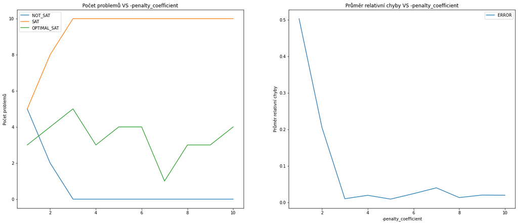

```
Celkovy počet problem 10
+----------------------+-----------------------+------------------+------------------------------+
| -penalty_coefficient | Počet není SAT rešení | Počet SAT rešení | Počet optimalních SAT rešení |
+----------------------+-----------------------+------------------+------------------------------+
|          1           |           5           |        5         |              3               |
|          2           |           2           |        8         |              4               |
|          3           |           0           |        10        |              5               |
|          4           |           0           |        10        |              3               |
|          5           |           0           |        10        |              4               |
|          6           |           0           |        10        |              4               |
|          7           |           0           |        10        |              1               |
|          8           |           0           |        10        |              3               |
|          9           |           0           |        10        |              3               |
|          10          |           0           |        10        |              4               |
+----------------------+-----------------------+------------------+------------------------------+
```

```python
# 1. Display _Problems count & _Mean relative error plots:
df_analytics = algorithm_outputs_penalty_coefficient.copy()
error_mean_table = pd.pivot_table(
    data=df_analytics,
    values='ERROR',
    index='-penalty_coefficient',
    aggfunc=np.mean
)

data = {
    'NOT_SAT': [],
    'SAT': [],
    'OPTIMAL_SAT': []
}
parameter_name = next(iter(penalty_coefficient_parameter.keys()))
for value in next(iter(penalty_coefficient_parameter.values())):
    data['NOT_SAT'].append(df_analytics[(df_analytics['SATISFIED'] == False) & (df_analytics[parameter_name] == value)].count()['SATISFIED'])
    data['SAT'].append(df_analytics[(df_analytics['SATISFIED'] == True) & (df_analytics[parameter_name] == value)].count()['SATISFIED'])
    data['OPTIMAL_SAT'].append(df_analytics[
        (df_analytics['SATISFIED'] == True) &
        (df_analytics['ERROR'] == 0.0) &
        (df_analytics[parameter_name] == value)
    ].count()['SATISFIED'])

df_sat = pd.DataFrame(data, index = next(iter(penalty_coefficient_parameter.values())))

_, axes = plt.subplots(nrows=1, ncols=2, figsize=(22,9))
# decrease size of legend
plt.rc('legend',fontsize=10)


ax = df_sat.plot(y=["NOT_SAT", "SAT", "OPTIMAL_SAT"], use_index=True, title=f"Počet problemů VS -penalty_coefficient", ax=axes[0])
ax.set_ylabel('Počet problemů')
ax = error_mean_table.plot(title=f"Průměr relativní chyby VS -penalty_coefficient", ax=axes[1])
ax.set_ylabel('Průměr relativní chyby')
plt.show()


# 2. Display sat table analytics:
display_sat_table_analysis(
    parameter_with_range_to_test=penalty_coefficient_parameter,
    df=algorithm_outputs_penalty_coefficient
)
```

- algoritmus vždy dokáže najít ohodnocení literalu, při kterém formule bude splněna
- relativní chyba je nejmenší

**Poznámka**: první graf Nám říká, že při zpracování 10 vstupních instancí:

- $\text{NOT_SAT}$ - pro kolik instanci nebylo nalezené takové ohodnocení, aby formule byla splněna,
- $\text{SAT}$ - pro kolik instanci bylo nalezené takové ohodnocení, aby formule byla splněna,
- $\text{OPTIMAL_SAT}$ - nalezené ohodnocení je optimální (t.j. relatvni chyba je nulová)

### Závislosti kvality řešení a výpočetní náročnosti algoritmu na parametrech

Jak již bylo zmíněno dříve, všechna měření se provádí na 10 instancích ze souboru **wuf50-201-M**. Výsledky jsou zprůmerovany. Ve všech provedených měřeních vždy měníme pouze jeden parametr, ostatní zůstavají fixní.

#### Počáteční teplota [ $\textbf{-initial_temperature}$ ]

Následující test se zabývá citlivosti na počáteční teplotu **-𝐢𝐧𝐢𝐭𝐢𝐚𝐥_𝐭𝐞𝐦𝐩𝐞𝐫𝐚𝐭𝐮𝐫𝐞**. Pro testování zvolíme interval $[0, 1000]$ s krokem 100.

```python
args = DEFAULT_ARGS.copy()

initial_temperature_parameter = {
    # range -initial_temperature <0, 1000>
    '-initial_temperature': range(0, 1000 + 1, 100)
}

algorithm_outputs_initial_temperature = solve_instance_using_simulated_annealing(
    parameter_with_range_to_test=initial_temperature_parameter,
    args=args
)
```

```
[INFO]: testing parameter  -initial_temperature=0
 - Solving input instances.. :wuf50-0123.mwcnf, wuf50-012.mwcnf, wuf50-0133.mwcnf, wuf50-0139.mwcnf, wuf50-0241.mwcnf, wuf50-024.mwcnf, wuf50-0274.mwcnf, wuf50-0369.mwcnf, wuf50-036.mwcnf, wuf50-0405.mwcnf..
[INFO]: testing parameter  -initial_temperature=100
 - Solving input instances.. :wuf50-0123.mwcnf, wuf50-012.mwcnf, wuf50-0133.mwcnf, wuf50-0139.mwcnf, wuf50-0241.mwcnf, wuf50-024.mwcnf, wuf50-0274.mwcnf, wuf50-0369.mwcnf, wuf50-036.mwcnf, wuf50-0405.mwcnf..
[INFO]: testing parameter  -initial_temperature=200
 - Solving input instances.. :wuf50-0123.mwcnf, wuf50-012.mwcnf, wuf50-0133.mwcnf, wuf50-0139.mwcnf, wuf50-0241.mwcnf, wuf50-024.mwcnf, wuf50-0274.mwcnf, wuf50-0369.mwcnf, wuf50-036.mwcnf, wuf50-0405.mwcnf..
[INFO]: testing parameter  -initial_temperature=300
 - Solving input instances.. :wuf50-0123.mwcnf, wuf50-012.mwcnf, wuf50-0133.mwcnf, wuf50-0139.mwcnf, wuf50-0241.mwcnf, wuf50-024.mwcnf, wuf50-0274.mwcnf, wuf50-0369.mwcnf, wuf50-036.mwcnf, wuf50-0405.mwcnf..
[INFO]: testing parameter  -initial_temperature=400
 - Solving input instances.. :wuf50-0123.mwcnf, wuf50-012.mwcnf, wuf50-0133.mwcnf, wuf50-0139.mwcnf, wuf50-0241.mwcnf, wuf50-024.mwcnf, wuf50-0274.mwcnf, wuf50-0369.mwcnf, wuf50-036.mwcnf, wuf50-0405.mwcnf..
[INFO]: testing parameter  -initial_temperature=500
 - Solving input instances.. :wuf50-0123.mwcnf, wuf50-012.mwcnf, wuf50-0133.mwcnf, wuf50-0139.mwcnf, wuf50-0241.mwcnf, wuf50-024.mwcnf, wuf50-0274.mwcnf, wuf50-0369.mwcnf, wuf50-036.mwcnf, wuf50-0405.mwcnf..
[INFO]: testing parameter  -initial_temperature=600
 - Solving input instances.. :wuf50-0123.mwcnf, wuf50-012.mwcnf, wuf50-0133.mwcnf, wuf50-0139.mwcnf, wuf50-0241.mwcnf, wuf50-024.mwcnf, wuf50-0274.mwcnf, wuf50-0369.mwcnf, wuf50-036.mwcnf, wuf50-0405.mwcnf..
[INFO]: testing parameter  -initial_temperature=700
 - Solving input instances.. :wuf50-0123.mwcnf, wuf50-012.mwcnf, wuf50-0133.mwcnf, wuf50-0139.mwcnf, wuf50-0241.mwcnf, wuf50-024.mwcnf, wuf50-0274.mwcnf, wuf50-0369.mwcnf, wuf50-036.mwcnf, wuf50-0405.mwcnf..
[INFO]: testing parameter  -initial_temperature=800
 - Solving input instances.. :wuf50-0123.mwcnf, wuf50-012.mwcnf, wuf50-0133.mwcnf, wuf50-0139.mwcnf, wuf50-0241.mwcnf, wuf50-024.mwcnf, wuf50-0274.mwcnf, wuf50-0369.mwcnf, wuf50-036.mwcnf, wuf50-0405.mwcnf..
[INFO]: testing parameter  -initial_temperature=900
 - Solving input instances.. :wuf50-0123.mwcnf, wuf50-012.mwcnf, wuf50-0133.mwcnf, wuf50-0139.mwcnf, wuf50-0241.mwcnf, wuf50-024.mwcnf, wuf50-0274.mwcnf, wuf50-0369.mwcnf, wuf50-036.mwcnf, wuf50-0405.mwcnf..
[INFO]: testing parameter  -initial_temperature=1000
 - Solving input instances.. :wuf50-0123.mwcnf, wuf50-012.mwcnf, wuf50-0133.mwcnf, wuf50-0139.mwcnf, wuf50-0241.mwcnf, wuf50-024.mwcnf, wuf50-0274.mwcnf, wuf50-0369.mwcnf, wuf50-036.mwcnf, wuf50-0405.mwcnf..
```

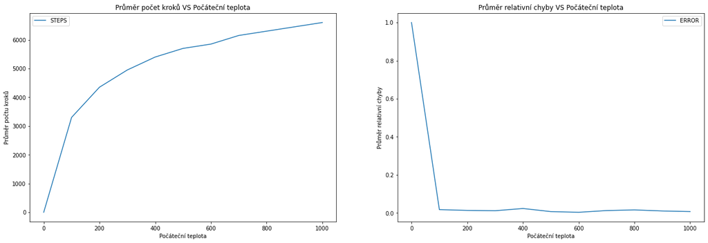

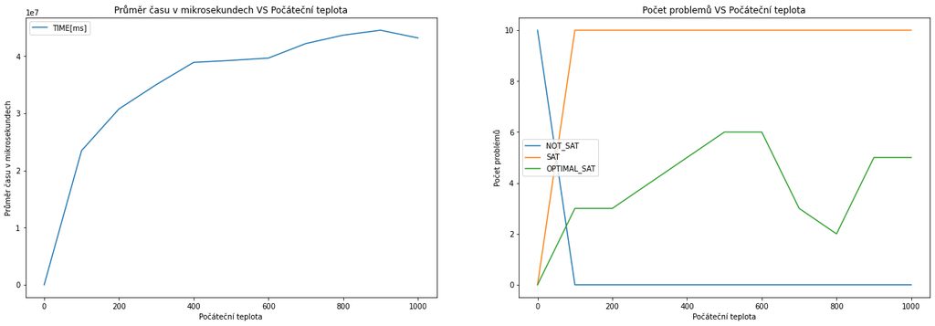

```
Celkovy počet problémů 10
+----------------------+-----------------------+------------------+------------------------------+
| -initial_temperature | Počet není SAT rešení | Počet SAT rešení | Počet optimalních SAT rešení |
+----------------------+-----------------------+------------------+------------------------------+
|          0           |           10          |        0         |              0               |
|         100          |           0           |        10        |              3               |
|         200          |           0           |        10        |              3               |
|         300          |           0           |        10        |              4               |
|         400          |           0           |        10        |              5               |
|         500          |           0           |        10        |              6               |
|         600          |           0           |        10        |              6               |
|         700          |           0           |        10        |              3               |
|         800          |           0           |        10        |              2               |
|         900          |           0           |        10        |              5               |
|         1000         |           0           |        10        |              5               |
+----------------------+-----------------------+------------------+------------------------------+
```

```python
plot_basic_analytics(
    algorithm_outputs=algorithm_outputs_initial_temperature,
    parameter_with_range_to_test=initial_temperature_parameter,
    index_column=next(iter(initial_temperature_parameter)),
    parameter_label='Počáteční teplota'
)

display_sat_table_analysis(
    parameter_with_range_to_test=initial_temperature_parameter,
    df=algorithm_outputs_initial_temperature
)
```

Probereme a provedeme analýzu vykreslených grafů.

##### $\textbf{- Počet navštívených stavů:}$

Z grafu je vidět, že při zvyšování počáteční teploty, roste počet prohledovanych stavů. Stejně tak, stojí za zmínku, že koefficient ochlazování se nemění, proto je logicky, že roste počet kroků abychom se dostali na minimální teplotu.

##### $\textbf{- Časová složitost:}$

Počáteční teplota, stejně jak minimální teplota, má přímý vliv na počet iteraci vnějšího cyklu. Je vidět, že s věští hodnotou počáteční teploty roste i čas. Nejdříve je růst významný, ale po čase se trochu uklidní.

##### $\textbf{- Počet problémů:}$

Z grafu je vidět, že skoro ideální nastavení počáteční teploty je v rozmezí $\text{500-600}$, neboť počet optimálních nalezených řešení je největší. Stojí za povšimnutí, že algoritmus pro každou hondotu pocateceni teploty větší než *100* dokáže najít takové ohodnocení folrmule, aby ona byla splněna.

##### Vývoj vahy v zavislosti na počtu navštívených stavů

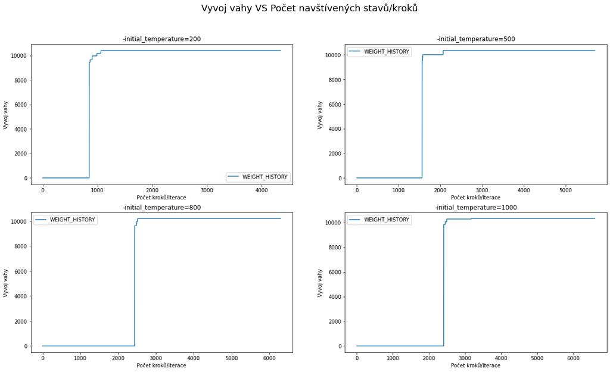

```python
plot_weight_evalution_history(
    algorithm_output=algorithm_outputs_initial_temperature,
    parameter_column_name='-initial_temperature',
    index_values=[200, 500, 800, 1000]
)
```

#### Koeficient ochlazování [ $\textbf{-cooling_coefficient}$ ]

Následující test se zabývá citlivosti na koeficient ochlazování **-cooling_coefficient**. Pro testování zvolíme interval $[0,8, 0.99]$ s krokem 0.01.

```python
args = DEFAULT_ARGS.copy()

cooling_coefficient_parameter = {
    # range -initial_temperature <0.8, 0.99>
    '-cooling_coefficient': np.round(np.arange(0.8, 0.99 + 0.01, 0.01), 2)
}

algorithm_outputs_cooling_coefficient = solve_instance_using_simulated_annealing(
    parameter_with_range_to_test=cooling_coefficient_parameter,
    args=args
)
```

```
[INFO]: testing parameter  -cooling_coefficient=0.8
 - Solving input instances.. :wuf50-0123.mwcnf, wuf50-012.mwcnf, wuf50-0133.mwcnf, wuf50-0139.mwcnf, wuf50-0241.mwcnf, wuf50-024.mwcnf, wuf50-0274.mwcnf, wuf50-0369.mwcnf, wuf50-036.mwcnf, wuf50-0405.mwcnf..
[INFO]: testing parameter  -cooling_coefficient=0.81
 - Solving input instances.. :wuf50-0123.mwcnf, wuf50-012.mwcnf, wuf50-0133.mwcnf, wuf50-0139.mwcnf, wuf50-0241.mwcnf, wuf50-024.mwcnf, wuf50-0274.mwcnf, wuf50-0369.mwcnf, wuf50-036.mwcnf, wuf50-0405.mwcnf..
[INFO]: testing parameter  -cooling_coefficient=0.82
 - Solving input instances.. :wuf50-0123.mwcnf, wuf50-012.mwcnf, wuf50-0133.mwcnf, wuf50-0139.mwcnf, wuf50-0241.mwcnf, wuf50-024.mwcnf, wuf50-0274.mwcnf, wuf50-0369.mwcnf, wuf50-036.mwcnf, wuf50-0405.mwcnf..
[INFO]: testing parameter  -cooling_coefficient=0.83
 - Solving input instances.. :wuf50-0123.mwcnf, wuf50-012.mwcnf, wuf50-0133.mwcnf, wuf50-0139.mwcnf, wuf50-0241.mwcnf, wuf50-024.mwcnf, wuf50-0274.mwcnf, wuf50-0369.mwcnf, wuf50-036.mwcnf, wuf50-0405.mwcnf..
[INFO]: testing parameter  -cooling_coefficient=0.84
 - Solving input instances.. :wuf50-0123.mwcnf, wuf50-012.mwcnf, wuf50-0133.mwcnf, wuf50-0139.mwcnf, wuf50-0241.mwcnf, wuf50-024.mwcnf, wuf50-0274.mwcnf, wuf50-0369.mwcnf, wuf50-036.mwcnf, wuf50-0405.mwcnf..
[INFO]: testing parameter  -cooling_coefficient=0.85
 - Solving input instances.. :wuf50-0123.mwcnf, wuf50-012.mwcnf, wuf50-0133.mwcnf, wuf50-0139.mwcnf, wuf50-0241.mwcnf, wuf50-024.mwcnf, wuf50-0274.mwcnf, wuf50-0369.mwcnf, wuf50-036.mwcnf, wuf50-0405.mwcnf..
[INFO]: testing parameter  -cooling_coefficient=0.86
 - Solving input instances.. :wuf50-0123.mwcnf, wuf50-012.mwcnf, wuf50-0133.mwcnf, wuf50-0139.mwcnf, wuf50-0241.mwcnf, wuf50-024.mwcnf, wuf50-0274.mwcnf, wuf50-0369.mwcnf, wuf50-036.mwcnf, wuf50-0405.mwcnf..
[INFO]: testing parameter  -cooling_coefficient=0.87
 - Solving input instances.. :wuf50-0123.mwcnf, wuf50-012.mwcnf, wuf50-0133.mwcnf, wuf50-0139.mwcnf, wuf50-0241.mwcnf, wuf50-024.mwcnf, wuf50-0274.mwcnf, wuf50-0369.mwcnf, wuf50-036.mwcnf, wuf50-0405.mwcnf..
[INFO]: testing parameter  -cooling_coefficient=0.88
 - Solving input instances.. :wuf50-0123.mwcnf, wuf50-012.mwcnf, wuf50-0133.mwcnf, wuf50-0139.mwcnf, wuf50-0241.mwcnf, wuf50-024.mwcnf, wuf50-0274.mwcnf, wuf50-0369.mwcnf, wuf50-036.mwcnf, wuf50-0405.mwcnf..
[INFO]: testing parameter  -cooling_coefficient=0.89
 - Solving input instances.. :wuf50-0123.mwcnf, wuf50-012.mwcnf, wuf50-0133.mwcnf, wuf50-0139.mwcnf, wuf50-0241.mwcnf, wuf50-024.mwcnf, wuf50-0274.mwcnf, wuf50-0369.mwcnf, wuf50-036.mwcnf, wuf50-0405.mwcnf..
[INFO]: testing parameter  -cooling_coefficient=0.9
 - Solving input instances.. :wuf50-0123.mwcnf, wuf50-012.mwcnf, wuf50-0133.mwcnf, wuf50-0139.mwcnf, wuf50-0241.mwcnf, wuf50-024.mwcnf, wuf50-0274.mwcnf, wuf50-0369.mwcnf, wuf50-036.mwcnf, wuf50-0405.mwcnf..
[INFO]: testing parameter  -cooling_coefficient=0.91
 - Solving input instances.. :wuf50-0123.mwcnf, wuf50-012.mwcnf, wuf50-0133.mwcnf, wuf50-0139.mwcnf, wuf50-0241.mwcnf, wuf50-024.mwcnf, wuf50-0274.mwcnf, wuf50-0369.mwcnf, wuf50-036.mwcnf, wuf50-0405.mwcnf..
[INFO]: testing parameter  -cooling_coefficient=0.92
 - Solving input instances.. :wuf50-0123.mwcnf, wuf50-012.mwcnf, wuf50-0133.mwcnf, wuf50-0139.mwcnf, wuf50-0241.mwcnf, wuf50-024.mwcnf, wuf50-0274.mwcnf, wuf50-0369.mwcnf, wuf50-036.mwcnf, wuf50-0405.mwcnf..
[INFO]: testing parameter  -cooling_coefficient=0.93
 - Solving input instances.. :wuf50-0123.mwcnf, wuf50-012.mwcnf, wuf50-0133.mwcnf, wuf50-0139.mwcnf, wuf50-0241.mwcnf, wuf50-024.mwcnf, wuf50-0274.mwcnf, wuf50-0369.mwcnf, wuf50-036.mwcnf, wuf50-0405.mwcnf..
[INFO]: testing parameter  -cooling_coefficient=0.94
 - Solving input instances.. :wuf50-0123.mwcnf, wuf50-012.mwcnf, wuf50-0133.mwcnf, wuf50-0139.mwcnf, wuf50-0241.mwcnf, wuf50-024.mwcnf, wuf50-0274.mwcnf, wuf50-0369.mwcnf, wuf50-036.mwcnf, wuf50-0405.mwcnf..
[INFO]: testing parameter  -cooling_coefficient=0.95
 - Solving input instances.. :wuf50-0123.mwcnf, wuf50-012.mwcnf, wuf50-0133.mwcnf, wuf50-0139.mwcnf, wuf50-0241.mwcnf, wuf50-024.mwcnf, wuf50-0274.mwcnf, wuf50-0369.mwcnf, wuf50-036.mwcnf, wuf50-0405.mwcnf..
[INFO]: testing parameter  -cooling_coefficient=0.96
 - Solving input instances.. :wuf50-0123.mwcnf, wuf50-012.mwcnf, wuf50-0133.mwcnf, wuf50-0139.mwcnf, wuf50-0241.mwcnf, wuf50-024.mwcnf, wuf50-0274.mwcnf, wuf50-0369.mwcnf, wuf50-036.mwcnf, wuf50-0405.mwcnf..
[INFO]: testing parameter  -cooling_coefficient=0.97
 - Solving input instances.. :wuf50-0123.mwcnf, wuf50-012.mwcnf, wuf50-0133.mwcnf, wuf50-0139.mwcnf, wuf50-0241.mwcnf, wuf50-024.mwcnf, wuf50-0274.mwcnf, wuf50-0369.mwcnf, wuf50-036.mwcnf, wuf50-0405.mwcnf..
[INFO]: testing parameter  -cooling_coefficient=0.98
 - Solving input instances.. :wuf50-0123.mwcnf, wuf50-012.mwcnf, wuf50-0133.mwcnf, wuf50-0139.mwcnf, wuf50-0241.mwcnf, wuf50-024.mwcnf, wuf50-0274.mwcnf, wuf50-0369.mwcnf, wuf50-036.mwcnf, wuf50-0405.mwcnf..
[INFO]: testing parameter  -cooling_coefficient=0.99
 - Solving input instances.. :wuf50-0123.mwcnf, wuf50-012.mwcnf, wuf50-0133.mwcnf, wuf50-0139.mwcnf, wuf50-0241.mwcnf, wuf50-024.mwcnf, wuf50-0274.mwcnf, wuf50-0369.mwcnf, wuf50-036.mwcnf, wuf50-0405.mwcnf..
```

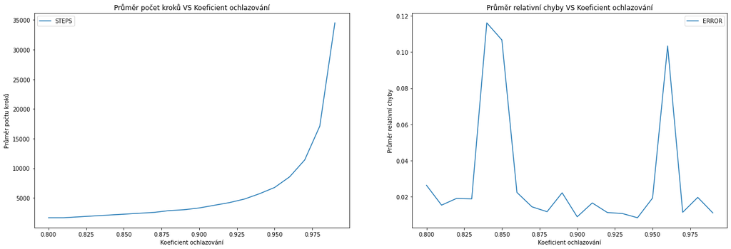

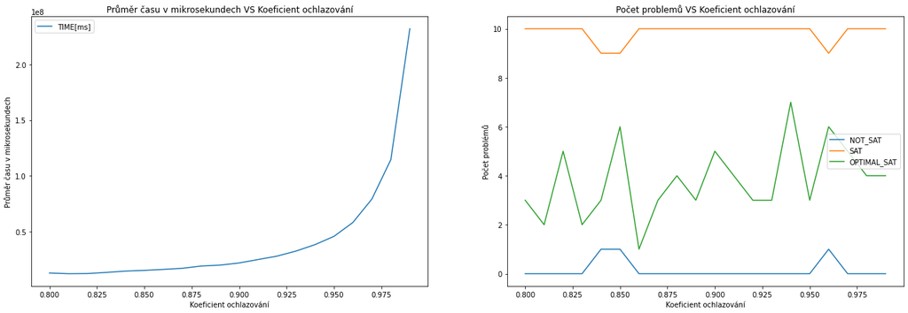

```
Celkovy počet problémů 10
+----------------------+-----------------------+------------------+------------------------------+
| -cooling_coefficient | Počet není SAT rešení | Počet SAT rešení | Počet optimalních SAT rešení |
+----------------------+-----------------------+------------------+------------------------------+
|         0.8          |           0           |        10        |              3               |
|         0.81         |           0           |        10        |              2               |
|         0.82         |           0           |        10        |              5               |
|         0.83         |           0           |        10        |              2               |
|         0.84         |           1           |        9         |              3               |
|         0.85         |           1           |        9         |              6               |
|         0.86         |           0           |        10        |              1               |
|         0.87         |           0           |        10        |              3               |
|         0.88         |           0           |        10        |              4               |
|         0.89         |           0           |        10        |              3               |
|         0.9          |           0           |        10        |              5               |
|         0.91         |           0           |        10        |              4               |
|         0.92         |           0           |        10        |              3               |
|         0.93         |           0           |        10        |              3               |
|         0.94         |           0           |        10        |              7               |
|         0.95         |           0           |        10        |              3               |
|         0.96         |           1           |        9         |              6               |
|         0.97         |           0           |        10        |              5               |
|         0.98         |           0           |        10        |              4               |
|         0.99         |           0           |        10        |              4               |
+----------------------+-----------------------+------------------+------------------------------+
```

```python
plot_basic_analytics(
    algorithm_outputs=algorithm_outputs_cooling_coefficient,
    parameter_with_range_to_test=cooling_coefficient_parameter,
    index_column=next(iter(cooling_coefficient_parameter)),
    parameter_label='Koeficient ochlazování'
)

display_sat_table_analysis(
    parameter_with_range_to_test=cooling_coefficient_parameter,
    df=algorithm_outputs_cooling_coefficient
)
```

Probereme a provedeme analýzu vykreslených grafů.

##### $\textbf{- Počet navštívených stavů:}$

Z grafu je vidět, že s rostoucí hodnotou koeficientu ochlazování roste počet prohledovanych stavů. Taky je dá se říct, že průběh je polynomiální. Pro hodnoty blízké k 1 je už nárůst počtu stavu exponenciální.

##### $\textbf{- Relativní chyba:}$

Dá se říct, že relativní chyba vždy má docelou nízkou hodnotu. Nikdy nestoupá výš, než *0.12*. Jinak vývoj je docela divný, má výchylky na intervalech $[0.84, 0.85]$ a $0.96$. Pokud koukneme na graf "Počet problémů", tak hned je vidět, že právě na těchto intervalech vznikají řešení, které nejsou SAT (splnitelné). Celkem vývoj relativní chyby má klesající trend.

##### $\textbf{- Časová složitost:}$

S rostoucím koeficientem ochlazování roste i časová narocnot. Stejně jak u grafu pročtu prozkoumaných stavu, dá se říct, že pro hodnoty blízké k 1 je už růst skoro exponecnialni.

##### $\textbf{- Počet problémů:}$

Jak již bylo zmíněno, že jsou dva intervaly na kterých vznikají řešení, které nejsou SAT. Jinak vhodné nastavení koeficientu ochlazování je možné odhadovat kolem **0.94**. Neboť má největší počet optimálních SAT řešení.

##### Vývoj vahy v zavislosti na počtu navštívených stavů

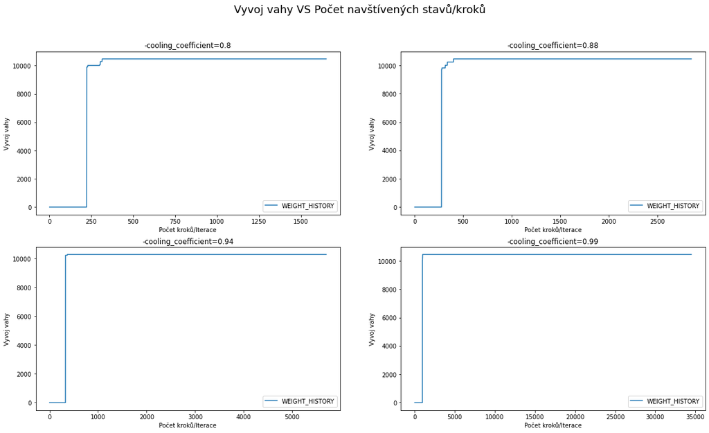

```python
plot_weight_evalution_history(
    algorithm_output=algorithm_outputs_cooling_coefficient,
    parameter_column_name='-cooling_coefficient',
    index_values=[0.8, 0.88, 0.94, 0.99]
)
```

#### Minimální teplota [ $\textbf{-minimal_temperature}$ ]

Následující test se zabývá citlivosti na hodnotu nastavené miminalni teploty **-minimal_temperature**. Pro testování zvolíme interval $[1, 99]$ s krokem 5.

```python
args = DEFAULT_ARGS.copy()

minimal_temperature_parameter = {
    # range -minimal_temperature <1, 99>
    '-minimal_temperature': range(1, 99 + 1, 5)
}

algorithm_outputs_minimal_temperature_parameter = solve_instance_using_simulated_annealing(
    parameter_with_range_to_test=minimal_temperature_parameter,
    args=args
)
```

```
[INFO]: testing parameter  -minimal_temperature=1
 - Solving input instances.. :wuf50-0123.mwcnf, wuf50-012.mwcnf, wuf50-0133.mwcnf, wuf50-0139.mwcnf, wuf50-0241.mwcnf, wuf50-024.mwcnf, wuf50-0274.mwcnf, wuf50-0369.mwcnf, wuf50-036.mwcnf, wuf50-0405.mwcnf..
[INFO]: testing parameter  -minimal_temperature=6
 - Solving input instances.. :wuf50-0123.mwcnf, wuf50-012.mwcnf, wuf50-0133.mwcnf, wuf50-0139.mwcnf, wuf50-0241.mwcnf, wuf50-024.mwcnf, wuf50-0274.mwcnf, wuf50-0369.mwcnf, wuf50-036.mwcnf, wuf50-0405.mwcnf..
[INFO]: testing parameter  -minimal_temperature=11
 - Solving input instances.. :wuf50-0123.mwcnf, wuf50-012.mwcnf, wuf50-0133.mwcnf, wuf50-0139.mwcnf, wuf50-0241.mwcnf, wuf50-024.mwcnf, wuf50-0274.mwcnf, wuf50-0369.mwcnf, wuf50-036.mwcnf, wuf50-0405.mwcnf..
[INFO]: testing parameter  -minimal_temperature=16
 - Solving input instances.. :wuf50-0123.mwcnf, wuf50-012.mwcnf, wuf50-0133.mwcnf, wuf50-0139.mwcnf, wuf50-0241.mwcnf, wuf50-024.mwcnf, wuf50-0274.mwcnf, wuf50-0369.mwcnf, wuf50-036.mwcnf, wuf50-0405.mwcnf..
[INFO]: testing parameter  -minimal_temperature=21
 - Solving input instances.. :wuf50-0123.mwcnf, wuf50-012.mwcnf, wuf50-0133.mwcnf, wuf50-0139.mwcnf, wuf50-0241.mwcnf, wuf50-024.mwcnf, wuf50-0274.mwcnf, wuf50-0369.mwcnf, wuf50-036.mwcnf, wuf50-0405.mwcnf..
[INFO]: testing parameter  -minimal_temperature=26
 - Solving input instances.. :wuf50-0123.mwcnf, wuf50-012.mwcnf, wuf50-0133.mwcnf, wuf50-0139.mwcnf, wuf50-0241.mwcnf, wuf50-024.mwcnf, wuf50-0274.mwcnf, wuf50-0369.mwcnf, wuf50-036.mwcnf, wuf50-0405.mwcnf..
[INFO]: testing parameter  -minimal_temperature=31
 - Solving input instances.. :wuf50-0123.mwcnf, wuf50-012.mwcnf, wuf50-0133.mwcnf, wuf50-0139.mwcnf, wuf50-0241.mwcnf, wuf50-024.mwcnf, wuf50-0274.mwcnf, wuf50-0369.mwcnf, wuf50-036.mwcnf, wuf50-0405.mwcnf..
[INFO]: testing parameter  -minimal_temperature=36
 - Solving input instances.. :wuf50-0123.mwcnf, wuf50-012.mwcnf, wuf50-0133.mwcnf, wuf50-0139.mwcnf, wuf50-0241.mwcnf, wuf50-024.mwcnf, wuf50-0274.mwcnf, wuf50-0369.mwcnf, wuf50-036.mwcnf, wuf50-0405.mwcnf..
[INFO]: testing parameter  -minimal_temperature=41
 - Solving input instances.. :wuf50-0123.mwcnf, wuf50-012.mwcnf, wuf50-0133.mwcnf, wuf50-0139.mwcnf, wuf50-0241.mwcnf, wuf50-024.mwcnf, wuf50-0274.mwcnf, wuf50-0369.mwcnf, wuf50-036.mwcnf, wuf50-0405.mwcnf..
[INFO]: testing parameter  -minimal_temperature=46
 - Solving input instances.. :wuf50-0123.mwcnf, wuf50-012.mwcnf, wuf50-0133.mwcnf, wuf50-0139.mwcnf, wuf50-0241.mwcnf, wuf50-024.mwcnf, wuf50-0274.mwcnf, wuf50-0369.mwcnf, wuf50-036.mwcnf, wuf50-0405.mwcnf..
[INFO]: testing parameter  -minimal_temperature=51
 - Solving input instances.. :wuf50-0123.mwcnf, wuf50-012.mwcnf, wuf50-0133.mwcnf, wuf50-0139.mwcnf, wuf50-0241.mwcnf, wuf50-024.mwcnf, wuf50-0274.mwcnf, wuf50-0369.mwcnf, wuf50-036.mwcnf, wuf50-0405.mwcnf..
[INFO]: testing parameter  -minimal_temperature=56
 - Solving input instances.. :wuf50-0123.mwcnf, wuf50-012.mwcnf, wuf50-0133.mwcnf, wuf50-0139.mwcnf, wuf50-0241.mwcnf, wuf50-024.mwcnf, wuf50-0274.mwcnf, wuf50-0369.mwcnf, wuf50-036.mwcnf, wuf50-0405.mwcnf..
[INFO]: testing parameter  -minimal_temperature=61
 - Solving input instances.. :wuf50-0123.mwcnf, wuf50-012.mwcnf, wuf50-0133.mwcnf, wuf50-0139.mwcnf, wuf50-0241.mwcnf, wuf50-024.mwcnf, wuf50-0274.mwcnf, wuf50-0369.mwcnf, wuf50-036.mwcnf, wuf50-0405.mwcnf..
[INFO]: testing parameter  -minimal_temperature=66
 - Solving input instances.. :wuf50-0123.mwcnf, wuf50-012.mwcnf, wuf50-0133.mwcnf, wuf50-0139.mwcnf, wuf50-0241.mwcnf, wuf50-024.mwcnf, wuf50-0274.mwcnf, wuf50-0369.mwcnf, wuf50-036.mwcnf, wuf50-0405.mwcnf..
[INFO]: testing parameter  -minimal_temperature=71
 - Solving input instances.. :wuf50-0123.mwcnf, wuf50-012.mwcnf, wuf50-0133.mwcnf, wuf50-0139.mwcnf, wuf50-0241.mwcnf, wuf50-024.mwcnf, wuf50-0274.mwcnf, wuf50-0369.mwcnf, wuf50-036.mwcnf, wuf50-0405.mwcnf..
[INFO]: testing parameter  -minimal_temperature=76
 - Solving input instances.. :wuf50-0123.mwcnf, wuf50-012.mwcnf, wuf50-0133.mwcnf, wuf50-0139.mwcnf, wuf50-0241.mwcnf, wuf50-024.mwcnf, wuf50-0274.mwcnf, wuf50-0369.mwcnf, wuf50-036.mwcnf, wuf50-0405.mwcnf..
[INFO]: testing parameter  -minimal_temperature=81
 - Solving input instances.. :wuf50-0123.mwcnf, wuf50-012.mwcnf, wuf50-0133.mwcnf, wuf50-0139.mwcnf, wuf50-0241.mwcnf, wuf50-024.mwcnf, wuf50-0274.mwcnf, wuf50-0369.mwcnf, wuf50-036.mwcnf, wuf50-0405.mwcnf..
[INFO]: testing parameter  -minimal_temperature=86
 - Solving input instances.. :wuf50-0123.mwcnf, wuf50-012.mwcnf, wuf50-0133.mwcnf, wuf50-0139.mwcnf, wuf50-0241.mwcnf, wuf50-024.mwcnf, wuf50-0274.mwcnf, wuf50-0369.mwcnf, wuf50-036.mwcnf, wuf50-0405.mwcnf..
[INFO]: testing parameter  -minimal_temperature=91
 - Solving input instances.. :wuf50-0123.mwcnf, wuf50-012.mwcnf, wuf50-0133.mwcnf, wuf50-0139.mwcnf, wuf50-0241.mwcnf, wuf50-024.mwcnf, wuf50-0274.mwcnf, wuf50-0369.mwcnf, wuf50-036.mwcnf, wuf50-0405.mwcnf..
[INFO]: testing parameter  -minimal_temperature=96
 - Solving input instances.. :wuf50-0123.mwcnf, wuf50-012.mwcnf, wuf50-0133.mwcnf, wuf50-0139.mwcnf, wuf50-0241.mwcnf, wuf50-024.mwcnf, wuf50-0274.mwcnf, wuf50-0369.mwcnf, wuf50-036.mwcnf, wuf50-0405.mwcnf..
```

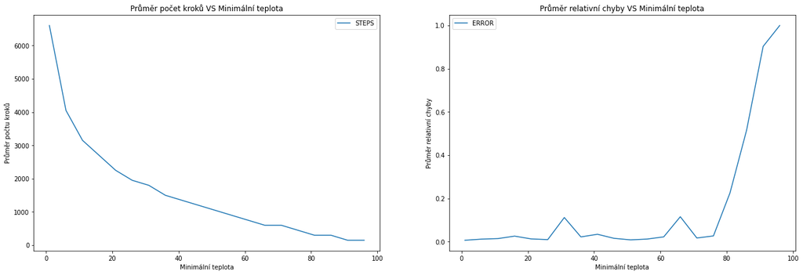

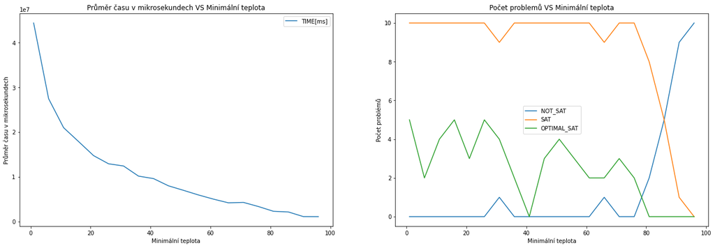

```
Celkovy počet problémů 10
+----------------------+-----------------------+------------------+------------------------------+
| -minimal_temperature | Počet není SAT rešení | Počet SAT rešení | Počet optimalních SAT rešení |
+----------------------+-----------------------+------------------+------------------------------+
|          1           |           0           |        10        |              5               |
|          6           |           0           |        10        |              2               |
|          11          |           0           |        10        |              4               |
|          16          |           0           |        10        |              5               |
|          21          |           0           |        10        |              3               |
|          26          |           0           |        10        |              5               |
|          31          |           1           |        9         |              4               |
|          36          |           0           |        10        |              2               |
|          41          |           0           |        10        |              0               |
|          46          |           0           |        10        |              3               |
|          51          |           0           |        10        |              4               |
|          56          |           0           |        10        |              3               |
|          61          |           0           |        10        |              2               |
|          66          |           1           |        9         |              2               |
|          71          |           0           |        10        |              3               |
|          76          |           0           |        10        |              2               |
|          81          |           2           |        8         |              0               |
|          86          |           5           |        5         |              0               |
|          91          |           9           |        1         |              0               |
|          96          |           10          |        0         |              0               |
+----------------------+-----------------------+------------------+------------------------------+
```

```python
plot_basic_analytics(
    algorithm_outputs=algorithm_outputs_minimal_temperature_parameter,
    parameter_with_range_to_test=minimal_temperature_parameter,
    index_column=next(iter(minimal_temperature_parameter)),
    parameter_label='Minimální teplota'
)

display_sat_table_analysis(
    parameter_with_range_to_test=minimal_temperature_parameter,
    df=algorithm_outputs_minimal_temperature_parameter
)
```

Probereme a provedeme analýzu vykreslených grafů.

##### $\textbf{- Počet navštívených stavů:}$

Je jasný, že se zvýšením minimlani teploty zastavíme algoritmus dříve, neboť parameter má přímý vliv na vnější cyklus algoritmu. Zmenšuje se stavový prostor, který prohledáváme.

##### $\textbf{- Relativní chyba:}$

Vývoj relativní chyby je docela konstantní. Vypadá, že na zkoumaném intervalu minimální teplota nemá vliv na kvalitu řešení. Avšak jediné co jde říct, že u teplot se blížících počáteční teplotě relativní chyba je větší, neboť zastavujeme algoritmus příliš brzo, neproběhne ještě dostatek iteraci pro nalezení lepších řešení a jsou přijímána horší řešení.

##### $\textbf{- Časová složitost:}$

Stejně jak u grafu počtu navštívených stavů se zvýšením minimální teplty zmenšuje se doba výpočtu.

##### $\textbf{- Počet problémů:}$

Dá se říct, že hodnoty testované hodnoty minimální teploty na zvoleném intervalu nemají příliš vysoký vliv na výsledky algoritmu. Je jasný, že u teplot se blížících počáteční teplotě bude klesat počet nalezených řešení. Třeba u *96* všechna nalezena řešení nejsou SAT. Z vykreslené tabulky šlo by říct, že ideální hodnota pro minimální teplotu je **1**, neboť má největší počet nalezených optimálních SAT řešení.

##### Vývoj vahy v zavislosti na počtu navštívených stavů

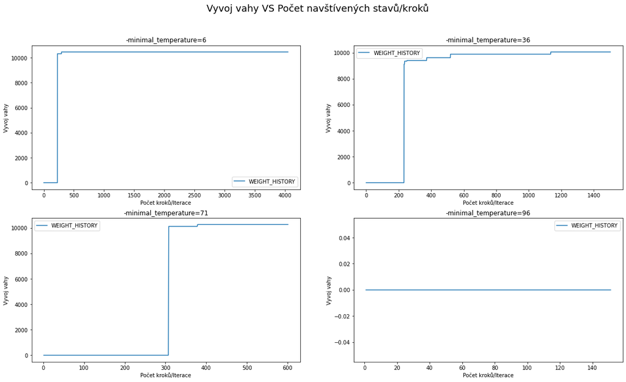

```python
plot_weight_evalution_history(
    algorithm_output=algorithm_outputs_minimal_temperature_parameter,
    parameter_column_name='-minimal_temperature',
    index_values=[6, 36, 71, 96]
)
```

#### Equilibrium [ $\textbf{-equilibrium_coefficient}$ ]

Následující test se zabývá citlivosti na equilibriu **-equilibrium_coefficient**. Pro testování zvolíme interval $[0, 50]$ s krokem 5.

```python
args = DEFAULT_ARGS.copy()

equilibrium_parameter = {
    # range -minimal_temperature <1, 99>
    '-equilibrium_coefficient': range(0, 50 + 1, 5)
}

algorithm_outputs_equilibrium = solve_instance_using_simulated_annealing(
    parameter_with_range_to_test=equilibrium_parameter,
    args=args
)
```

```
[INFO]: testing parameter  -equilibrium_coefficient=0
 - Solving input instances.. :wuf50-0123.mwcnf, wuf50-012.mwcnf, wuf50-0133.mwcnf, wuf50-0139.mwcnf, wuf50-0241.mwcnf, wuf50-024.mwcnf, wuf50-0274.mwcnf, wuf50-0369.mwcnf, wuf50-036.mwcnf, wuf50-0405.mwcnf..
[INFO]: testing parameter  -equilibrium_coefficient=5
 - Solving input instances.. :wuf50-0123.mwcnf, wuf50-012.mwcnf, wuf50-0133.mwcnf, wuf50-0139.mwcnf, wuf50-0241.mwcnf, wuf50-024.mwcnf, wuf50-0274.mwcnf, wuf50-0369.mwcnf, wuf50-036.mwcnf, wuf50-0405.mwcnf..
[INFO]: testing parameter  -equilibrium_coefficient=10
 - Solving input instances.. :wuf50-0123.mwcnf, wuf50-012.mwcnf, wuf50-0133.mwcnf, wuf50-0139.mwcnf, wuf50-0241.mwcnf, wuf50-024.mwcnf, wuf50-0274.mwcnf, wuf50-0369.mwcnf, wuf50-036.mwcnf, wuf50-0405.mwcnf..
[INFO]: testing parameter  -equilibrium_coefficient=15
 - Solving input instances.. :wuf50-0123.mwcnf, wuf50-012.mwcnf, wuf50-0133.mwcnf, wuf50-0139.mwcnf, wuf50-0241.mwcnf, wuf50-024.mwcnf, wuf50-0274.mwcnf, wuf50-0369.mwcnf, wuf50-036.mwcnf, wuf50-0405.mwcnf..
[INFO]: testing parameter  -equilibrium_coefficient=20
 - Solving input instances.. :wuf50-0123.mwcnf, wuf50-012.mwcnf, wuf50-0133.mwcnf, wuf50-0139.mwcnf, wuf50-0241.mwcnf, wuf50-024.mwcnf, wuf50-0274.mwcnf, wuf50-0369.mwcnf, wuf50-036.mwcnf, wuf50-0405.mwcnf..
[INFO]: testing parameter  -equilibrium_coefficient=25
 - Solving input instances.. :wuf50-0123.mwcnf, wuf50-012.mwcnf, wuf50-0133.mwcnf, wuf50-0139.mwcnf, wuf50-0241.mwcnf, wuf50-024.mwcnf, wuf50-0274.mwcnf, wuf50-0369.mwcnf, wuf50-036.mwcnf, wuf50-0405.mwcnf..
[INFO]: testing parameter  -equilibrium_coefficient=30
 - Solving input instances.. :wuf50-0123.mwcnf, wuf50-012.mwcnf, wuf50-0133.mwcnf, wuf50-0139.mwcnf, wuf50-0241.mwcnf, wuf50-024.mwcnf, wuf50-0274.mwcnf, wuf50-0369.mwcnf, wuf50-036.mwcnf, wuf50-0405.mwcnf..
[INFO]: testing parameter  -equilibrium_coefficient=35
 - Solving input instances.. :wuf50-0123.mwcnf, wuf50-012.mwcnf, wuf50-0133.mwcnf, wuf50-0139.mwcnf, wuf50-0241.mwcnf, wuf50-024.mwcnf, wuf50-0274.mwcnf, wuf50-0369.mwcnf, wuf50-036.mwcnf, wuf50-0405.mwcnf..
[INFO]: testing parameter  -equilibrium_coefficient=40
 - Solving input instances.. :wuf50-0123.mwcnf, wuf50-012.mwcnf, wuf50-0133.mwcnf, wuf50-0139.mwcnf, wuf50-0241.mwcnf, wuf50-024.mwcnf, wuf50-0274.mwcnf, wuf50-0369.mwcnf, wuf50-036.mwcnf, wuf50-0405.mwcnf..
[INFO]: testing parameter  -equilibrium_coefficient=45
 - Solving input instances.. :wuf50-0123.mwcnf, wuf50-012.mwcnf, wuf50-0133.mwcnf, wuf50-0139.mwcnf, wuf50-0241.mwcnf, wuf50-024.mwcnf, wuf50-0274.mwcnf, wuf50-0369.mwcnf, wuf50-036.mwcnf, wuf50-0405.mwcnf..
[INFO]: testing parameter  -equilibrium_coefficient=50
 - Solving input instances.. :wuf50-0123.mwcnf, wuf50-012.mwcnf, wuf50-0133.mwcnf, wuf50-0139.mwcnf, wuf50-0241.mwcnf, wuf50-024.mwcnf, wuf50-0274.mwcnf, wuf50-0369.mwcnf, wuf50-036.mwcnf, wuf50-0405.mwcnf..
```

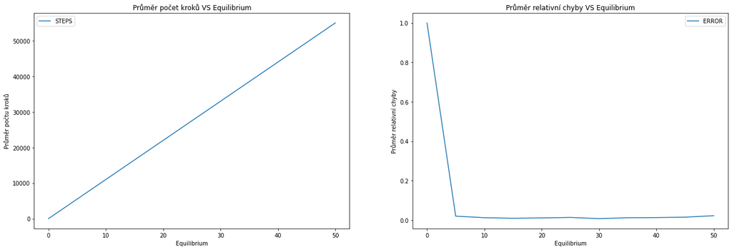

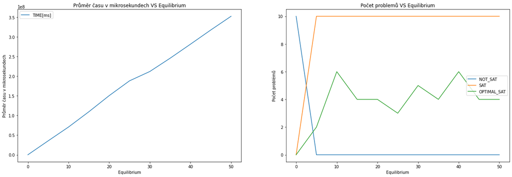

```
Celkovy počet problémů 10
+--------------------------+-----------------------+------------------+------------------------------+
| -equilibrium_coefficient | Počet není SAT rešení | Počet SAT rešení | Počet optimalních SAT rešení |
+--------------------------+-----------------------+------------------+------------------------------+
|            0             |           10          |        0         |              0               |
|            5             |           0           |        10        |              2               |
|            10            |           0           |        10        |              6               |
|            15            |           0           |        10        |              4               |
|            20            |           0           |        10        |              4               |
|            25            |           0           |        10        |              3               |
|            30            |           0           |        10        |              5               |
|            35            |           0           |        10        |              4               |
|            40            |           0           |        10        |              6               |
|            45            |           0           |        10        |              4               |
|            50            |           0           |        10        |              4               |
+--------------------------+-----------------------+------------------+------------------------------+
```

```python
plot_basic_analytics(
    algorithm_outputs=algorithm_outputs_equilibrium,
    parameter_with_range_to_test=equilibrium_parameter,
    index_column=next(iter(equilibrium_parameter)),
    parameter_label='Equilibrium'
)

display_sat_table_analysis(
    parameter_with_range_to_test=equilibrium_parameter,
    df=algorithm_outputs_equilibrium
)
```

Probereme a provedeme analýzu vykreslených grafů.

##### $\textbf{- Počet navštívených stavů:}$

Co by šlo říct z prvního pohledu na graf, tak že je viditelná lineární závislost počtu navštívených stavu na equilibriu, neboť roste počet provedení vnitřního cyklu.

##### $\textbf{- Relativní chyba:}$

S rostoucí hodnotou equilibria roste složitost algoritmu, stejně tak i roste počet nalezených řešení. Příliš malá hodnota omezuje počet generovaných stavů. Je viditelně, že equilibrium má značný vliv na relativní chybu. S rostoucím koeficientem equilibria klesá relativní chyba. Závislost chyby na equilibriu vypadá jako exponenciální. Avšak od hodnoty *5* se relativní chyby skoro nemění.

##### $\textbf{- Časová složitost:}$

Vlastně tady pozorujeme to samé, co i na grafu počtu navštívených stavu. Časová složitost s velikosti equilibria roste lineárně. Divná vychylka na grafu jsou nejspis kluli přetížení počítače (v důsledku zatížení RAM nebo něco podobného).

##### $\textbf{- Počet problémů:}$

Z grafu je vidět, že už od hodnoty *5* algoritmus vždy dokáže najít SAT řešení pro zkušební instanci. Co se týče nalezení optimálního řešení, tak z grafu nejde 100% tvrdit, že s větší hodnotou equilibria roste i počet nalezených optimálních řešení, neboť maximum nalezených optimálních řešení máme zároveň u dvou hodnot equilibria a to jsou *10* a *40*. Bylo by logicky říct, že s rostoucí hodnotou equilibria měl by narůstat počet nalezenyh optimálních řešení. Aši potřebovali bychom mít buď větší počet zkusenbich instanci nebo žádat větší rozsah pro hodnoty equilibria, bohužel nemám pro tyto účely super počítač. Výpočet toho intervalu trval kolem 4 hodin. Takže můžeme udělat závěr, že z vykreslené by tabulky šlo říct, že ideální hodnota pro equilibrium pro žádané zkušební instací je buď **10** nebo **40**.

##### Vývoj vahy v zavislosti na počtu navštívených stavů

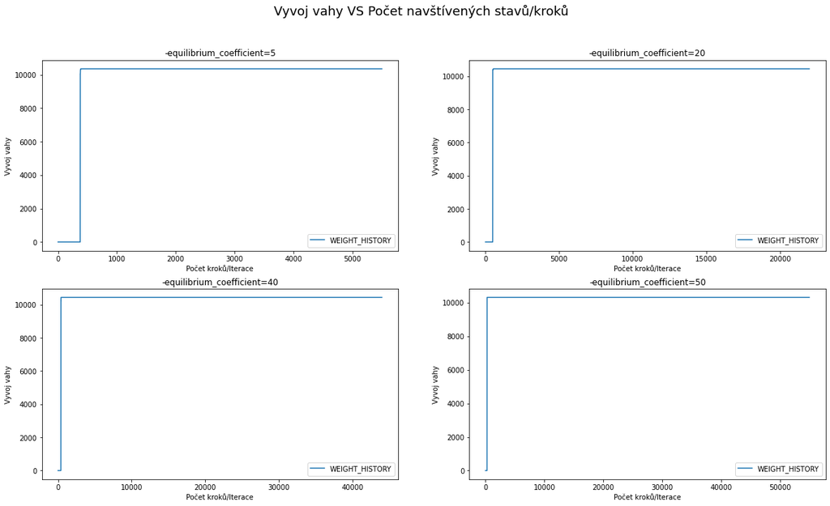

```python
plot_weight_evalution_history(
    algorithm_output=algorithm_outputs_equilibrium,
    parameter_column_name='-equilibrium_coefficient',
    index_values=[5, 20, 40, 50]
)
```

### Volba počátečního stavu

Jak jsem již zmiňoval dříve, naiplementoval jsem několik možnosti volby počátečního stavu. Je jasný, že volba pocatechniho stavu nemá žádný vliv na čas běhu algoritmu a počet prozkoumaných stavu.

Provedeme pár experimentu a zjistíme, jestli způsob generování počátečního stavu má nějaký vliv výslednou kvalitu řešení.

```python
AVAILABLE_STATES = ['all_false', 'random']

args = DEFAULT_ARGS.copy()
state_generator_parameter = {
    '-state_generator': AVAILABLE_STATES
}

algorithm_outputs_state_generator_parameter = solve_instance_using_simulated_annealing(
    parameter_with_range_to_test=state_generator_parameter,
    args=args
)
```

```
[INFO]: testing parameter  -state_generator=all_false
 - Solving input instances.. :wuf50-0123.mwcnf, wuf50-012.mwcnf, wuf50-0133.mwcnf, wuf50-0139.mwcnf, wuf50-0241.mwcnf, wuf50-024.mwcnf, wuf50-0274.mwcnf, wuf50-0369.mwcnf, wuf50-036.mwcnf, wuf50-0405.mwcnf..
[INFO]: testing parameter  -state_generator=random
 - Solving input instances.. :wuf50-0123.mwcnf, wuf50-012.mwcnf, wuf50-0133.mwcnf, wuf50-0139.mwcnf, wuf50-0241.mwcnf, wuf50-024.mwcnf, wuf50-0274.mwcnf, wuf50-0369.mwcnf, wuf50-036.mwcnf, wuf50-0405.mwcnf..
```

```
======================================== state generator = ALL_FALSE ========================================
```

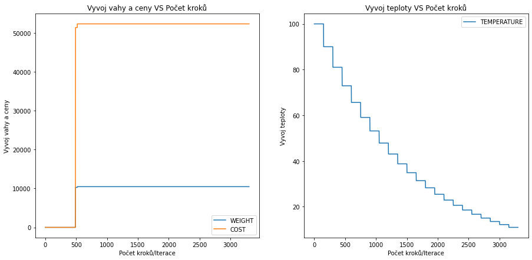

```
======================================== state generator = RANDOM ========================================
```

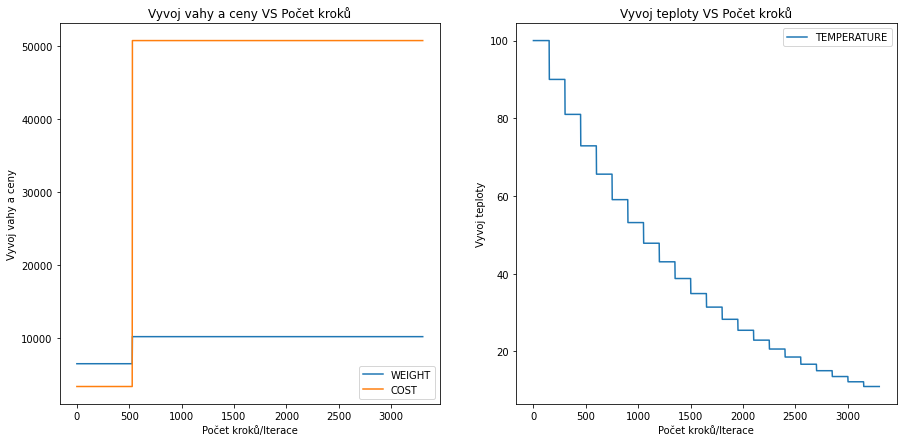

```python
for state_generator in AVAILABLE_STATES:
    print("="*40, "state generator =", state_generator.upper(), "="*40)

    plot_history_columns_evalution(
        algorithm_output=algorithm_outputs_state_generator_parameter.loc[algorithm_outputs_state_generator_parameter['-state_generator'] == state_generator]
    )
```

- modrou čarou na grafu zleva je označována váha, která je součtem všech vah všech literalu ohodnocených **True**
- žlutou čarou na grafu zleva je označována cena stavu, která se vypočítá dle vzorců popsaného v sekci *"Modifikace oproti problému bathou"*

Z výš vykreslených grafu plyne, že kvalita řešení není moc závislá na způsobu generování počátečního stavu. Je to jedno, jestli počáteční stav je generovaný způsobem "Všechny literaly nastavit na False" nebo "Náhodně ohodnocení literalů". Celkem by nemělo dojít k výraznému zlepšení výsledků. Váha bude každopádně konvergovat k optimální váze.

### Vývoj ceny a váhy v závislosti na teplotě

Koukneme ještě na graf vývoje ceny a teploty v závislosti na teplotě. Vezmeme náhodný sample z již minulých experimentů, jediné, omezíme se způsobu generování stavu "Všechny literaly nastavit na Falše".

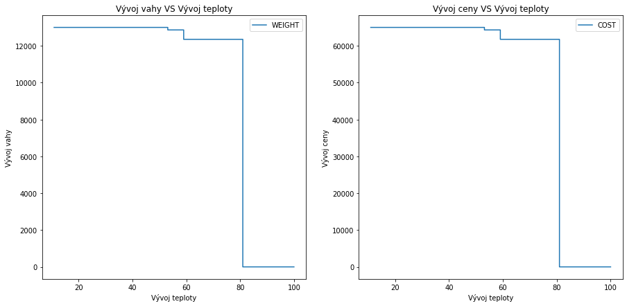

```python
algorithm_outputs_price_and_weight = algorithm_outputs_state_generator_parameter[
    algorithm_outputs_state_generator_parameter['-state_generator'] == 'all_false'
].copy()

history_table = pd.DataFrame(data={
    'WEIGHT': algorithm_outputs_price_and_weight['WEIGHT_HISTORY'].iloc[3].split(','),
    'COST': algorithm_outputs_price_and_weight['COSTS_HISTORY'].iloc[3].split(','),
    'TEMPERATURE': algorithm_outputs_price_and_weight['TEMPERATURE_HISTORY'].iloc[3].split(',')
})

history_table["WEIGHT"]=history_table["WEIGHT"].astype(int)
history_table["COST"]=history_table["COST"].astype(float)
history_table["TEMPERATURE"]=history_table["TEMPERATURE"].astype(float)
_, axes = plt.subplots(nrows=1, ncols=2, figsize=(15,7))

ax = history_table.plot(y='WEIGHT', x='TEMPERATURE', title=f"Vývoj vahy VS Vývoj teploty", ax=axes[0])
ax.set_ylabel('Vývoj vahy')
ax.set_xlabel('Vývoj teploty')

ax = history_table.plot(y='COST', x='TEMPERATURE', title=f"Vývoj ceny VS Vývoj teploty", ax=axes[1])
ax.set_ylabel('Vývoj ceny')
ax.set_xlabel('Vývoj teploty')

plt.show()
```

Z grafů je vidět, že hodnota váhy konverguje k optimální, při klesání počáteční teploty k minimální teplotě. Stejně tak dá se říct, že cena a váha se vyvíjí stejným způsobem.

## Závěr

Algoritmus simulovaného ochlazování je poměrně snadný na implementaci. Z provedených experimentu je vidět, že je docela vhodný na řešení problému problému vážené splnitelnosti booleovské formule.

Algoritmus má randomizovanou složku a právě volba sousedního stavu. Je třeba vyladit ho na co nejlepší poměr ceny řešení vzhledem k době výpočtu. Z naměřených hodnot je možné odhadnout vhodné nastavení algoritmu:

| 1 | Počáteční teplota | 500 |
| --- | --- | --- |
| 2 | Koeficient ochlazování | 0.94 |
| 3 | Minimální teplota | 1 |
| 4 | Equilibrium | 40 |

Algoritmus byl na zkušebních instancích docela úspěšný, skoro vždy při adekvátním nastavení hodnot, nalezl SAT řešení a dá se říct, že skoro v půlce případů to bylo optimální SAT řešení.

Algoritmus docela časově náročný. Algortmus skoro nezávisí na tom, jakým způsobem bude vygenerován počáteční stav. T.j. pokud inicializujeme algoritmus stavem generovaným randomnim způsobem, tak by nemělo dojít k výraznému zlepšení výsledků.